# 10 - Unsupervised Learning

Jaimie Bortolotti

March 28, 2019

Up until now, we’ve been given a set of $X$ values and response $Y$ values, and we have been building models using $X$ to predict $Y$ (=supervised learning). In unsupervised learning, we only have X values, and we are not concerned with prediction. Here, we want to explore the data - looking at subgroups, trends, and ways to visualize the data.

Unsupervised learning tends to be tricky as it is exploratory data analysis - there is no clearly outlined goal of analysis, and we cannot test our work like we have been using cross-validation to test the fit of our model (because here, there is no model).

Ex. If you have assayed gene expression levels in cancer patients, you can look for subgroups or patterns within those genes which can potentially help you understand the disease better.

There are two strategies: Principal Components Analysis and Clustering.

# PRINCIPAL COMPONENTS ANALYSIS

Principal components = when you have a large set of correlated variables, principal components are the subset of variables that explain the most variability within the data.

$p$ = # of features (variables) $n$ = observations

Example: USArrests per 100,000 residents for each of three crimes: Assault, Murder, Rape. Also includes UrbanPop (% of population living in urban areas)

$n=50$ (each state) $p=4$ (Assault, Murder, Rape, Urban Population)

The n observations are in p-dimensional space, but not all the dimensions are helpful in representing the data.

Ex. Movies are a 2D representation of 3D information - losing that 3rd dimension doesn’t affect the story or how the information is portrayed.

= dimension reduction

```r
USArrests
```

```
##                Murder Assault UrbanPop Rape
## Alabama          13.2     236       58 21.2
## Alaska           10.0     263       48 44.5
## Arizona           8.1     294       80 31.0
## Arkansas          8.8     190       50 19.5
## California        9.0     276       91 40.6
## Colorado          7.9     204       78 38.7
## Connecticut       3.3     110       77 11.1
## Delaware          5.9     238       72 15.8
## Florida          15.4     335       80 31.9
## Georgia          17.4     211       60 25.8
## Hawaii            5.3      46       83 20.2
## Idaho             2.6     120       54 14.2
## Illinois         10.4     249       83 24.0
## Indiana           7.2     113       65 21.0
## Iowa              2.2      56       57 11.3
## Kansas            6.0     115       66 18.0
## Kentucky          9.7     109       52 16.3
## Louisiana        15.4     249       66 22.2
## Maine             2.1      83       51  7.8
## Maryland         11.3     300       67 27.8
## Massachusetts     4.4     149       85 16.3
## Michigan         12.1     255       74 35.1
## Minnesota         2.7      72       66 14.9
## Mississippi      16.1     259       44 17.1
## Missouri          9.0     178       70 28.2
## Montana           6.0     109       53 16.4
## Nebraska          4.3     102       62 16.5
## Nevada           12.2     252       81 46.0
## New Hampshire     2.1      57       56  9.5
## New Jersey        7.4     159       89 18.8
## New Mexico       11.4     285       70 32.1
## New York         11.1     254       86 26.1
## North Carolina   13.0     337       45 16.1
## North Dakota      0.8      45       44  7.3
## Ohio              7.3     120       75 21.4
## Oklahoma          6.6     151       68 20.0
## Oregon            4.9     159       67 29.3
## Pennsylvania      6.3     106       72 14.9
## Rhode Island      3.4     174       87  8.3
## South Carolina   14.4     279       48 22.5
## South Dakota      3.8      86       45 12.8
## Tennessee        13.2     188       59 26.9
## Texas            12.7     201       80 25.5
## Utah              3.2     120       80 22.9
## Vermont           2.2      48       32 11.2
## Virginia          8.5     156       63 20.7
## Washington        4.0     145       73 26.2
## West Virginia     5.7      81       39  9.3
## Wisconsin         2.6      53       66 10.8
## Wyoming           6.8     161       60 15.6
```

First principal component ($Z1$) = normalized linear combination of features $(X_1, X_2, .. X_p)$ that has the largest variance.

Second principal component ($Z2$) = combination of features that has next highest variance that is uncorrelated with $Z1$, etc…

$z_{i1} = \phi_{11} x_{i1} + \phi_{21} x_{i2} + . . . + \phi_{p1}x{ip}$

$\phi$ = loadings

Loading = weight that each feature has in explaining variance

All the loadings combined = principle component loading vector - can plot on PCA graph, will show you relation to principal components, then you can compare observations to those trends.

Length and direction of each PC (Z) is determined by extreme values. Observations (in this case, states) are scored based on how much they influence each PC.

Little influence = closer to 0 Big influence (extreme value) = large number (can be either sign)

If we didn’t scale these variables, the variables with the biggest mean and variance would dominate (unhelpful if your variables are in different units). Scale to mean = 0, SD = 1 (use scale=TRUE)

```r
apply(USArrests, 2, mean)
```

```
##   Murder  Assault UrbanPop     Rape
##    7.788  170.760   65.540   21.232
```

```r
#applies the function mean() to each column (2) of USArrests

apply(USArrests, 2, var)
```

```
##     Murder    Assault   UrbanPop       Rape
##   18.97047 6945.16571  209.51878   87.72916
```

```r
#can perform PCA with prcomp(), set scale = TRUE

pr.out<-prcomp(USArrests, scale=TRUE)
names(pr.out)
```

```
## [1] "sdev"     "rotation" "center"   "scale"    "x"
```

Rotation = principal component loadings (each column contains loading vector) (for the features) x = principle component score vectors (for the observations)

4 columns = 4 PCs bc p = 4

```r
pr.out$rotation
```

```
##                 PC1        PC2        PC3         PC4
## Murder   -0.5358995  0.4181809 -0.3412327  0.64922780
## Assault  -0.5831836  0.1879856 -0.2681484 -0.74340748
## UrbanPop -0.2781909 -0.8728062 -0.3780158  0.13387773
## Rape     -0.5434321 -0.1673186  0.8177779  0.08902432
```

```r
pr.out$x
```

```
##                        PC1         PC2         PC3          PC4
## Alabama        -0.97566045  1.12200121 -0.43980366  0.154696581
## Alaska         -1.93053788  1.06242692  2.01950027 -0.434175454
## Arizona        -1.74544285 -0.73845954  0.05423025 -0.826264240
## Arkansas        0.13999894  1.10854226  0.11342217 -0.180973554
## California     -2.49861285 -1.52742672  0.59254100 -0.338559240
## Colorado       -1.49934074 -0.97762966  1.08400162  0.001450164
## Connecticut     1.34499236 -1.07798362 -0.63679250 -0.117278736
## Delaware       -0.04722981 -0.32208890 -0.71141032 -0.873113315
## Florida        -2.98275967  0.03883425 -0.57103206 -0.095317042
## Georgia        -1.62280742  1.26608838 -0.33901818  1.065974459
## Hawaii          0.90348448 -1.55467609  0.05027151  0.893733198
## Idaho           1.62331903  0.20885253  0.25719021 -0.494087852
## Illinois       -1.36505197 -0.67498834 -0.67068647 -0.120794916
## Indiana         0.50038122 -0.15003926  0.22576277  0.420397595
## Iowa            2.23099579 -0.10300828  0.16291036  0.017379470
## Kansas          0.78887206 -0.26744941  0.02529648  0.204421034
## Kentucky        0.74331256  0.94880748 -0.02808429  0.663817237
## Louisiana      -1.54909076  0.86230011 -0.77560598  0.450157791
## Maine           2.37274014  0.37260865 -0.06502225 -0.327138529
## Maryland       -1.74564663  0.42335704 -0.15566968 -0.553450589
## Massachusetts   0.48128007 -1.45967706 -0.60337172 -0.177793902
## Michigan       -2.08725025 -0.15383500  0.38100046  0.101343128
## Minnesota       1.67566951 -0.62590670  0.15153200  0.066640316
## Mississippi    -0.98647919  2.36973712 -0.73336290  0.213342049
## Missouri       -0.68978426 -0.26070794  0.37365033  0.223554811
## Montana         1.17353751  0.53147851  0.24440796  0.122498555
## Nebraska        1.25291625 -0.19200440  0.17380930  0.015733156
## Nevada         -2.84550542 -0.76780502  1.15168793  0.311354436
## New Hampshire   2.35995585 -0.01790055  0.03648498 -0.032804291
## New Jersey     -0.17974128 -1.43493745 -0.75677041  0.240936580
## New Mexico     -1.96012351  0.14141308  0.18184598 -0.336121113
## New York       -1.66566662 -0.81491072 -0.63661186 -0.013348844
## North Carolina -1.11208808  2.20561081 -0.85489245 -0.944789648
## North Dakota    2.96215223  0.59309738  0.29824930 -0.251434626
## Ohio            0.22369436 -0.73477837 -0.03082616  0.469152817
## Oklahoma        0.30864928 -0.28496113 -0.01515592  0.010228476
## Oregon         -0.05852787 -0.53596999  0.93038718 -0.235390872
## Pennsylvania    0.87948680 -0.56536050 -0.39660218  0.355452378
## Rhode Island    0.85509072 -1.47698328 -1.35617705 -0.607402746
## South Carolina -1.30744986  1.91397297 -0.29751723 -0.130145378
## South Dakota    1.96779669  0.81506822  0.38538073 -0.108470512
## Tennessee      -0.98969377  0.85160534  0.18619262  0.646302674
## Texas          -1.34151838 -0.40833518 -0.48712332  0.636731051
## Utah            0.54503180 -1.45671524  0.29077592 -0.081486749
## Vermont         2.77325613  1.38819435  0.83280797 -0.143433697
## Virginia        0.09536670  0.19772785  0.01159482  0.209246429
## Washington      0.21472339 -0.96037394  0.61859067 -0.218628161
## West Virginia   2.08739306  1.41052627  0.10372163  0.130583080
## Wisconsin       2.05881199 -0.60512507 -0.13746933  0.182253407
## Wyoming         0.62310061  0.31778662 -0.23824049 -0.164976866
```

First principal component = linear combination of features

$Z_1 = \phi_{11}X_1 + \phi_{21}X_2 + . . . + \phi_{p1}X_p$

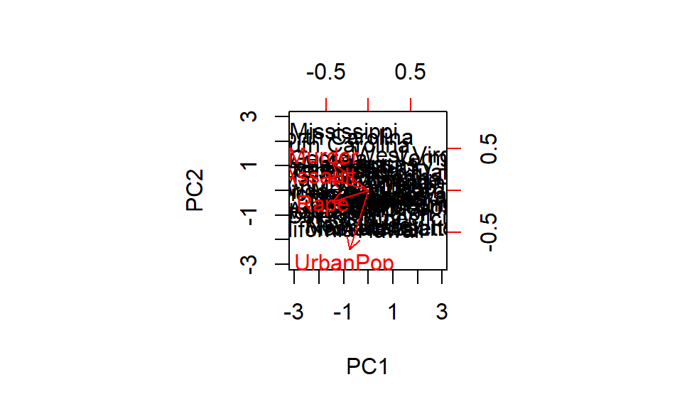

```r
biplot(pr.out, scale=0)
```

```r
#standard deviation
pr.out$sdev
```

```
## [1] 1.5748783 0.9948694 0.5971291 0.4164494
```

```r
#variance explained by each principal component
pr.var<-pr.out$sdev^2

#proportion of variance explained
pve<-pr.var/sum(pr.var)
pve
```

```
## [1] 0.62006039 0.24744129 0.08914080 0.04335752
```

PC1 explains 62.0% of variance PC2 explains 24.7% PC3 explains 8.9% PC4 explains 4.3%

So figure above visualizes ~85% of variation

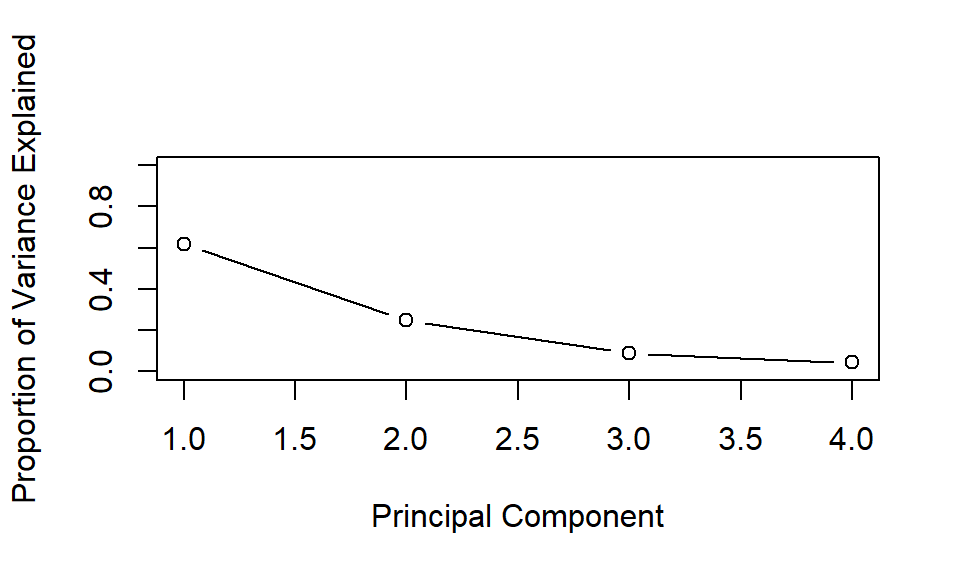

```r
plot(pve,
     xlab="Principal Component",
     ylab="Proportion of Variance Explained",
     ylim=c(0,1),
     type="b")
```

Can plot this cumulatively as well:

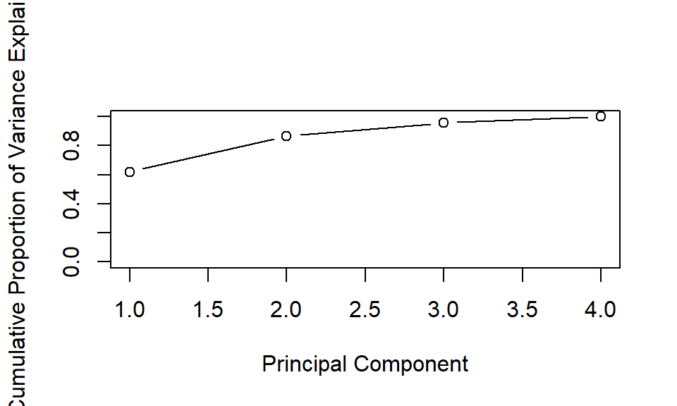

```r
plot(cumsum(pve),
     xlab="Principal Component",
     ylab="Cumulative Proportion of Variance Explained",
     ylim=c(0,1),
     type="b")
```

At this point, you could plot the other principal components, but PC3 and PC4 explain so little of the variance (<15% combined) that the original plot of PC1 vs PC2 gives the best picture of the data.

## UMAP

Used for non-linear dimension reduction (non-parametric data) - very useful when working with high-dimensional/complicated genetic data, etc.

```r
library(umap)
```

Separate data and labels

```r
iris.data<-iris[,grep("Sepal|Petal", colnames(iris))]
iris.labels<-iris[,"Species"]
```

```r
iris.umap<-umap(iris.data)
iris.umap
```

```
## umap embedding of 150 items in 2 dimensions
## object components: layout, data, knn, config
```

Layout is a matrix of coordinates that correspond to the positions on the umap graph (scores, like above)

```r
head(iris.umap$layout)
```

```
##          [,1]      [,2]
## [1,] 7.807925 1.4938803
## [2,] 7.515388 3.2259893
## [3,] 8.067802 3.1166512
## [4,] 8.022198 3.2902741
## [5,] 8.075376 1.2406382
## [6,] 7.797964 0.3288711
```

```r
#Fancy custom plot from https://cran.r-project.org/web/packages/umap/vignettes/umap.html

plot.iris<-function(x, labels,
                    main="A UMAP visualization of the Iris dataset",
                    pad=0.1,
                    cex=0.65,
                    pch=19,
                    add=FALSE,
                    legend.suffix="",
                    cex.main=1,
                    cex.legend=1) {

 layout = x
 if (class(x)=="umap") {
   layout = x$layout
   }

 xylim = range(layout)
 xylim = xylim + ((xylim[2]-xylim[1])*pad)*c(-0.5, 0.5)

 if (!add) {
     par(mar=c(0.2,0.7,1.2,0.7), ps=10)
     plot(xylim,
          xylim,
          type="n",
          axes=F,
          frame=F)
     rect(xylim[1],
          xylim[1],
          xylim[2],
          xylim[2],
          border="#aaaaaa",
          lwd=0.25)
   }

 points(layout[,1],
        layout[,2],
        col=as.integer(labels),
        cex=cex,
        pch=pch)
 mtext(side=3,
       main,
       cex=cex.main)

   labels.u = unique(labels)
   legend.pos = "bottomright"
   legend.text = as.character(labels.u)
   if (add) {
     legend.pos = "bottomright"
     legend.text = paste(as.character(labels.u),
                         legend.suffix)
   }

   legend(legend.pos,
          legend=legend.text,
          col=as.integer(labels.u),
          bty="n",
          pch=pch,
          cex=cex.legend)
 }
```

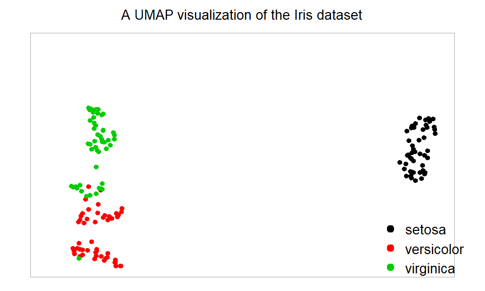

```r
plot.iris(iris.umap, iris.labels)
```

Most of the variation in the data can be explained by species, as there is distinct clustering.

# CLUSTERING

Clustering refers to finding subgroups within a dataset.

Ex. n observations with p features.

$n$ observations = tissue samples from breast cancer patients $p$ features = measurements from each tissue sample (tumor stage, etc.)

Are there different subtypes of breast cancer that we don’t know about?

*PCA* looks to find low-dimensional representation of observations that explains high fraction of variance

*Clustering* looks to find homogeneous subgroups among observations

Two clustering approaches: K-means and hierarchal

## K-means Clustering

Goal: Partition the observations into pre-specified number of clusters.

1. Randomly assign a number from 1 to K (K = # of clusters) to each observation. These are initial cluster assignments.
2. Iterate until the cluster assignments stop changing.
1. For each of the K clusters, compute centroid (vector of the p feature means for the observations in the kth cluster).
2. Assign each observation to the cluster whose centroid is closest (Euclidean distance).

You want to minimize variation in the cluster. Obviously, you could have K = n, with a variation of 0, but eventually the reduction in variation with increasing K will start to slow down, so pick the elbow.

```r
#create data set with 2 clusters

set.seed(2)
x=matrix(rnorm(50*2), ncol=2)
x[1:25,1]=x[1:25,1]+3
x[1:25,2]=x[1:25,2]-4
```

Perform K-means clustering with K=2

```r
#use kmeans()
#nstart = #of iterations

km.out=kmeans(x,2,nstart=20)
km.out$cluster
```

```
##  [1] 2 2 2 2 2 2 2 2 2 2 2 2 2 2 2 2 2 2 2 2 2 2 2 2 2 1 1 1 1 1 1 1 1 1 1
## [36] 1 1 1 1 1 1 1 1 1 1 1 1 1 1 1
```

*nstart* = used to run algorithm a bunch of times (here = 20); kmeans will only report best results (lowest sum of squares)

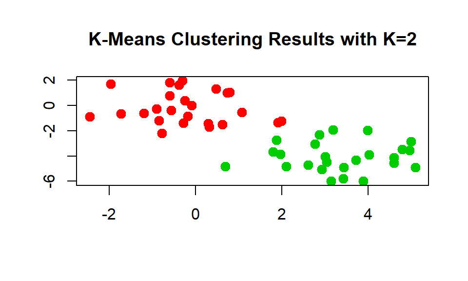

```r
plot(x,
     col=(km.out$cluster+1),
     main="K-Means Clustering Results with K=2",
     xlab="",
     ylab="",
     pch=20,
     cex=2)
```

For this example we knew there were 2 clusters, but in real data you wouldn’t - let’s try this with K = 3.

```r
set.seed(4)
km.out=kmeans(x,3,nstart=20)
km.out
```

```
## K-means clustering with 3 clusters of sizes 10, 23, 17
##
## Cluster means:
##         [,1]        [,2]
## 1  2.3001545 -2.69622023
## 2 -0.3820397 -0.08740753
## 3  3.7789567 -4.56200798
##
## Clustering vector:
##  [1] 3 1 3 1 3 3 3 1 3 1 3 1 3 1 3 1 3 3 3 3 3 1 3 3 3 2 2 2 2 2 2 2 2 2 2
## [36] 2 2 2 2 2 2 2 2 1 2 1 2 2 2 2
##
## Within cluster sum of squares by cluster:
## [1] 19.56137 52.67700 25.74089
##  (between_SS / total_SS =  79.3 %)
##
## Available components:
##
## [1] "cluster"      "centers"      "totss"        "withinss"
## [5] "tot.withinss" "betweenss"    "size"         "iter"
## [9] "ifault"
```

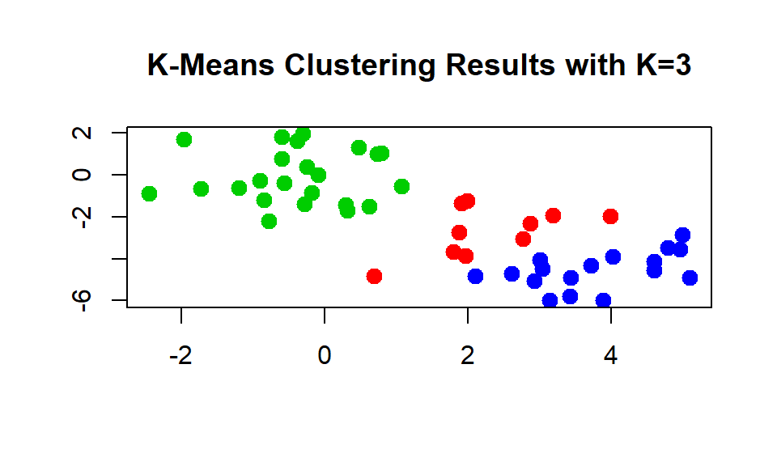

```r
plot(x,
     col=(km.out$cluster+1),
     main="K-Means Clustering Results with K=3",
     xlab ="",
     ylab="",
     pch =20,
     cex =2)
```

## Hierarchical Clustering

Use this when you don’t know how many clusters you want. This is a bottom-up approach.

```r
#use hclist(), specify strategy
#using random data from above

hc.complete<-hclust(dist(x), method="complete")
hc.average<-hclust(dist(x), method="average")
hc.single<-hclust(dist(x), method="single")
```

Three strategies for clustering:

Complete linkage clustering - merge clusters with smallest maximum pairwise distance (conservative)

Single linkage clustering - merge clusters with smallest minimum pairwise distance

Average linkage clustering - compromise between both

Plot dendrograms:

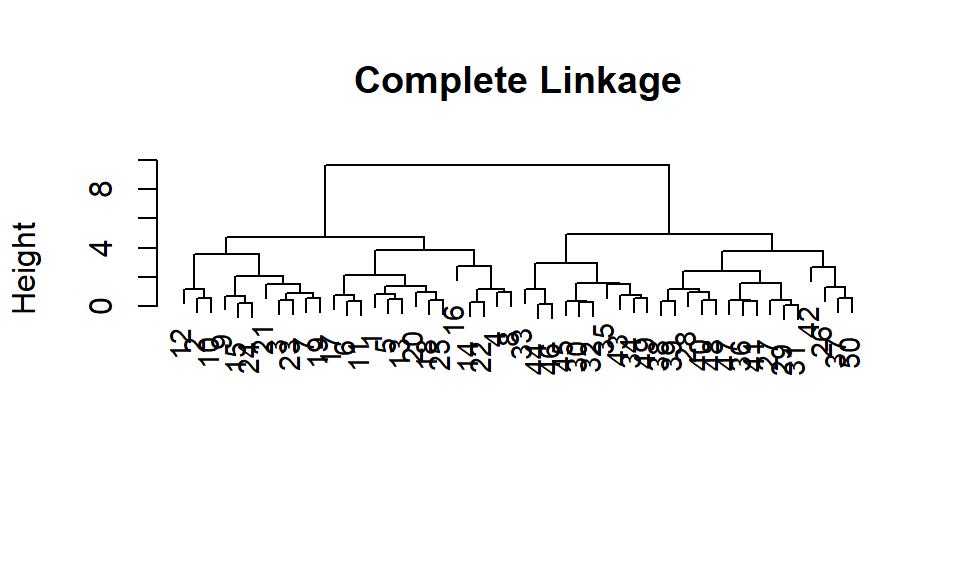

```r
plot(hc.complete,
     main="Complete Linkage",
     xlab="",
     sub="",
     cex=0.9)
```

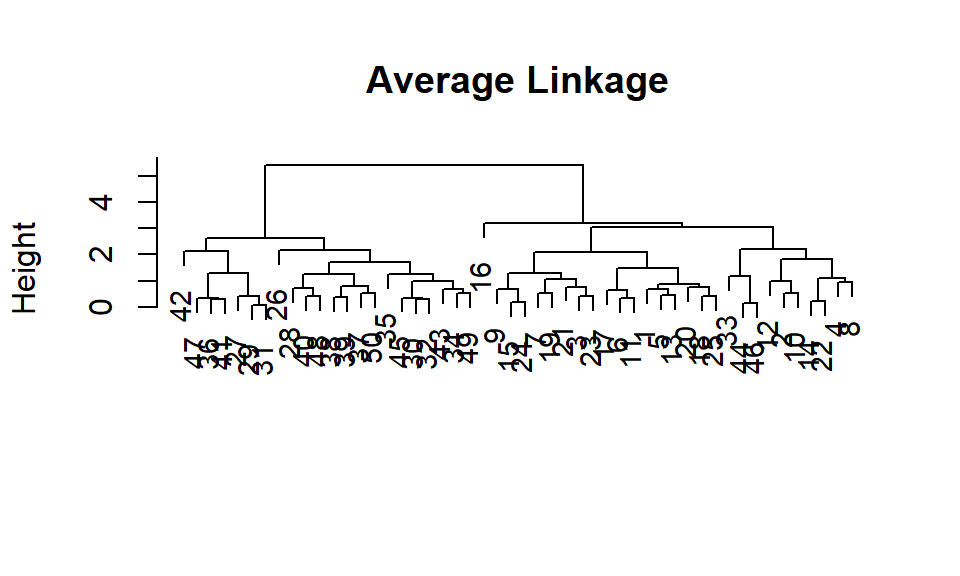

```r
plot(hc.average,
     main="Average Linkage",
     xlab="",
     sub="",
     cex=0.9)
```

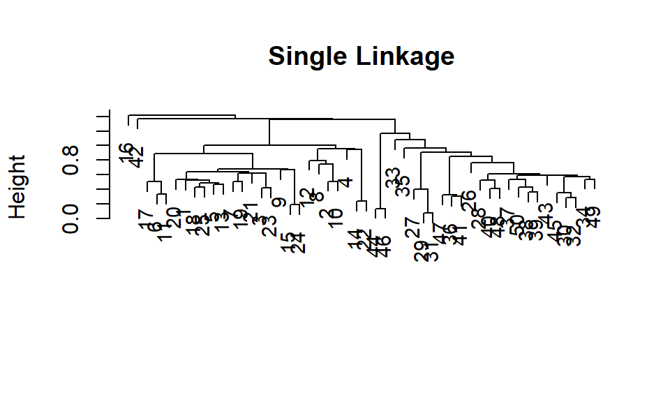

```r
plot(hc.single,
     main="Single Linkage",
     xlab="",
     sub="",
     cex=0.9)
```

cutree() = determines cluster labels (how many clusters you want to cut the data into)

```r
cutree(hc.complete, 2)
```

```
##  [1] 1 1 1 1 1 1 1 1 1 1 1 1 1 1 1 1 1 1 1 1 1 1 1 1 1 2 2 2 2 2 2 2 2 2 2
## [36] 2 2 2 2 2 2 2 2 2 2 2 2 2 2 2
```

```r
cutree(hc.average, 2)
```

```
##  [1] 1 1 1 1 1 1 1 1 1 1 1 1 1 1 1 1 1 1 1 1 1 1 1 1 1 2 2 2 2 2 2 2 1 2 2
## [36] 2 2 2 2 2 2 2 2 1 2 1 2 2 2 2
```

```r
cutree(hc.single, 2)
```

```
##  [1] 1 1 1 1 1 1 1 1 1 1 1 1 1 1 1 2 1 1 1 1 1 1 1 1 1 1 1 1 1 1 1 1 1 1 1
## [36] 1 1 1 1 1 1 1 1 1 1 1 1 1 1 1
```

Complete and average are pretty good at clustering - cuts the data more or less correctly into two clusters (which is what we designed the data to do). Single, on the other hand, identifies basically one big cluster with a lone data point in cluster 2.

Try with different cluster value:

```r
cutree(hc.single, 3)
```

```
##  [1] 1 1 1 1 1 1 1 1 1 1 1 1 1 1 1 2 1 1 1 1 1 1 1 1 1 1 1 1 1 1 1 1 1 1 1
## [36] 1 1 1 1 1 1 3 1 1 1 1 1 1 1 1
```

Still 2 lone clusters.

### GENETIC EXAMPLE

6830 gene expression measurements (columns) on 64 cancer cell lines (rows)

```r
library(ISLR)
ncilabs<-NCI60$labs
ncidat<-NCI60$data
```

```r
#look at types of cancer for the cell lines

table(ncilabs)
```

```
## ncilabs
##      BREAST         CNS       COLON K562A-repro K562B-repro    LEUKEMIA
##           7           5           7           1           1           6
## MCF7A-repro MCF7D-repro    MELANOMA       NSCLC     OVARIAN    PROSTATE
##           1           1           8           9           6           2
##       RENAL     UNKNOWN
##           9           1
```

PCA

```r
pr.out=prcomp(ncidat, scale=TRUE)

#colour code cancer types

Cols=function(vec){
  cols=rainbow(length(unique(vec)))
  return(cols[as.numeric(as.factor(vec))])
}
```

Plot 3 best principal components

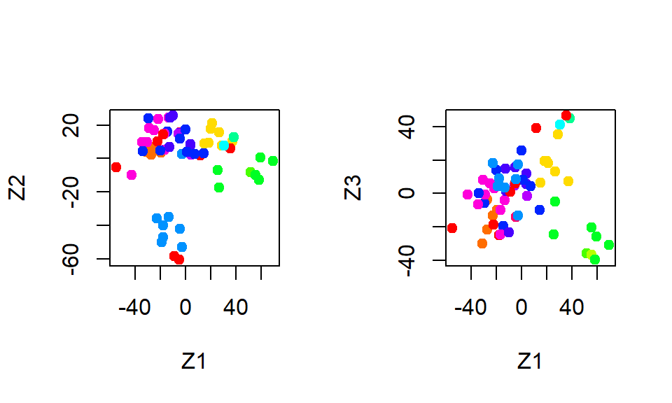

```r
par(mfrow=c(1,2))

plot(pr.out$x[,1:2],
     col=Cols(ncilabs),
     pch=19,
     xlab="Z1",
     ylab="Z2")

plot(pr.out$x[,c(1,3)],
     col=Cols(ncilabs),
     pch=19,
     xlab="Z1",
     ylab="Z3")
```

Overall, cancer types tend to cluster together, suggesting that cell lines from the same cancer type have similar gene expression levels.

PVE

```r
summary(pr.out)
```

```
## Importance of components:
##                            PC1      PC2      PC3      PC4      PC5
## Standard deviation     27.8535 21.48136 19.82046 17.03256 15.97181
## Proportion of Variance  0.1136  0.06756  0.05752  0.04248  0.03735
## Cumulative Proportion   0.1136  0.18115  0.23867  0.28115  0.31850
##                             PC6      PC7      PC8      PC9     PC10
## Standard deviation     15.72108 14.47145 13.54427 13.14400 12.73860
## Proportion of Variance  0.03619  0.03066  0.02686  0.02529  0.02376
## Cumulative Proportion   0.35468  0.38534  0.41220  0.43750  0.46126
##                            PC11     PC12     PC13     PC14     PC15
## Standard deviation     12.68672 12.15769 11.83019 11.62554 11.43779
## Proportion of Variance  0.02357  0.02164  0.02049  0.01979  0.01915
## Cumulative Proportion   0.48482  0.50646  0.52695  0.54674  0.56590
##                            PC16     PC17     PC18     PC19    PC20
## Standard deviation     11.00051 10.65666 10.48880 10.43518 10.3219
## Proportion of Variance  0.01772  0.01663  0.01611  0.01594  0.0156
## Cumulative Proportion   0.58361  0.60024  0.61635  0.63229  0.6479
##                            PC21    PC22    PC23    PC24    PC25    PC26
## Standard deviation     10.14608 10.0544 9.90265 9.64766 9.50764 9.33253
## Proportion of Variance  0.01507  0.0148 0.01436 0.01363 0.01324 0.01275
## Cumulative Proportion   0.66296  0.6778 0.69212 0.70575 0.71899 0.73174
##                           PC27   PC28    PC29    PC30    PC31    PC32
## Standard deviation     9.27320 9.0900 8.98117 8.75003 8.59962 8.44738
## Proportion of Variance 0.01259 0.0121 0.01181 0.01121 0.01083 0.01045
## Cumulative Proportion  0.74433 0.7564 0.76824 0.77945 0.79027 0.80072
##                           PC33    PC34    PC35    PC36    PC37    PC38
## Standard deviation     8.37305 8.21579 8.15731 7.97465 7.90446 7.82127
## Proportion of Variance 0.01026 0.00988 0.00974 0.00931 0.00915 0.00896
## Cumulative Proportion  0.81099 0.82087 0.83061 0.83992 0.84907 0.85803
##                           PC39    PC40    PC41   PC42    PC43   PC44
## Standard deviation     7.72156 7.58603 7.45619 7.3444 7.10449 7.0131
## Proportion of Variance 0.00873 0.00843 0.00814 0.0079 0.00739 0.0072
## Cumulative Proportion  0.86676 0.87518 0.88332 0.8912 0.89861 0.9058
##                           PC45   PC46    PC47    PC48    PC49    PC50
## Standard deviation     6.95839 6.8663 6.80744 6.64763 6.61607 6.40793
## Proportion of Variance 0.00709 0.0069 0.00678 0.00647 0.00641 0.00601
## Cumulative Proportion  0.91290 0.9198 0.92659 0.93306 0.93947 0.94548
##                           PC51    PC52    PC53    PC54    PC55    PC56
## Standard deviation     6.21984 6.20326 6.06706 5.91805 5.91233 5.73539
## Proportion of Variance 0.00566 0.00563 0.00539 0.00513 0.00512 0.00482
## Cumulative Proportion  0.95114 0.95678 0.96216 0.96729 0.97241 0.97723
##                           PC57   PC58    PC59    PC60    PC61    PC62
## Standard deviation     5.47261 5.2921 5.02117 4.68398 4.17567 4.08212
## Proportion of Variance 0.00438 0.0041 0.00369 0.00321 0.00255 0.00244
## Cumulative Proportion  0.98161 0.9857 0.98940 0.99262 0.99517 0.99761
##                           PC63      PC64
## Standard deviation     4.04124 2.148e-14
## Proportion of Variance 0.00239 0.000e+00
## Cumulative Proportion  1.00000 1.000e+00
```

```r
pve=100*pr.out$sdev^2/sum(pr.out$sdev^2)
```

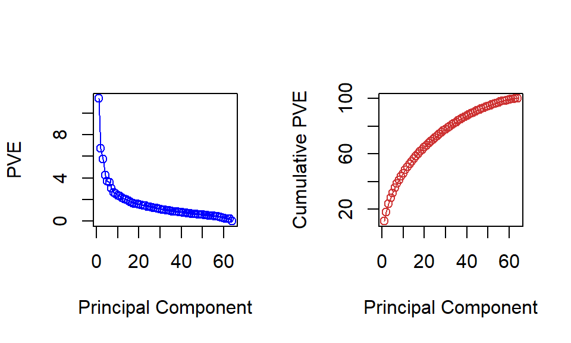

```r
par(mfrow=c(1,2))

plot(pve,
     type="o",
     ylab="PVE",
     xlab="Principal Component",
     col="blue")

plot(cumsum(pve),
     type="o",
     ylab="Cumulative PVE",
     xlab="Principal Component",
     col="brown3")
```

The first 7 PCs explain about 40% of the variance, and an elbow afterwards (diminishing returns)

From here, we want to hierarchially cluster the cell lines - do the observations cluster into distinct types of cancer?

Standardize data first:

```r
sd.data=scale(ncidat)
```

[figure not shown]

```r
data.dist=dist(sd.data)

plot(hclust(data.dist), #defaults to complete
     labels=ncilabs,
     main="Complete Linkage",
     xlab ="",
     sub ="",
     ylab ="")
```

[figure not shown]

```r
plot(hclust(data.dist, method ="average"),
     labels=ncilabs,
     main="Average Linkage",
     xlab ="",
     sub ="",
     ylab ="")
```

[figure not shown]

```r
plot(hclust(data.dist, method ="single"),
     labels =ncilabs,
     main="Single Linkage",
     xlab="",
     sub ="",
     ylab ="")
```

Pretty good clustering but not perfect. Let’s try cutting the dendrogram at a height that will yield 4 clusters:

```r
hc.out<-hclust(dist(sd.data)) #categorizes clusters

hc.clusters<-cutree(hc.out, 4)

table(hc.clusters, ncilabs)
```

```
##            ncilabs
## hc.clusters BREAST CNS COLON K562A-repro K562B-repro LEUKEMIA MCF7A-repro
##           1      2   3     2           0           0        0           0
##           2      3   2     0           0           0        0           0
##           3      0   0     0           1           1        6           0
##           4      2   0     5           0           0        0           1
##            ncilabs
## hc.clusters MCF7D-repro MELANOMA NSCLC OVARIAN PROSTATE RENAL UNKNOWN
##           1           0        8     8       6        2     8       1
##           2           0        0     1       0        0     1       0
##           3           0        0     0       0        0     0       0
##           4           1        0     0       0        0     0       0
```

[figure not shown]

```r
par(mfrow = c(1,1))
plot(hc.out, labels = ncilabs)
abline(h = 139, col ="red") #this is where you can cut it into 4 clusters
```

Try with K-means clustering with K=4 and compare

```r
set.seed(2)
km.out<-kmeans(sd.data, 4, nstart=20)
km.clusters<-km.out$cluster
table(km.clusters, hc.clusters)
```

```
##            hc.clusters
## km.clusters  1  2  3  4
##           1 11  0  0  9
##           2  0  0  8  0
##           3  9  0  0  0
##           4 20  7  0  0
```

These clusters are different: C2 in K-means is the same as C3 in Hierarchal, but C4 in K-means contains some C1 from Hierarchal and all of C2…

Sometimes performing HC on first couple PCs yields better results as it reduces noise in the data

[figure not shown]

```r
hc.out<-hclust(dist(pr.out$x[,1:5]))

plot(hc.out, labels=ncilabs,
     main="Hier. Clust on 1st 5 Score Vectors")
```

```r
table(cutree(hc.out, 4), ncilabs)
```

```
##    ncilabs
##     BREAST CNS COLON K562A-repro K562B-repro LEUKEMIA MCF7A-repro
##   1      0   2     7           0           0        2           0
##   2      5   3     0           0           0        0           0
##   3      0   0     0           1           1        4           0
##   4      2   0     0           0           0        0           1
##    ncilabs
##     MCF7D-repro MELANOMA NSCLC OVARIAN PROSTATE RENAL UNKNOWN
##   1           0        1     8       5        2     7       0
##   2           0        7     1       1        0     2       1
##   3           0        0     0       0        0     0       0
##   4           1        0     0       0        0     0       0
```

Different again…looks like better clustering